# PML project

Smita

9/16/2020

# Summary

In this project, the goal is to use data from accelerometers on the belt, forearm, arm, and dumbell of 6 participants. They were asked to perform barbell lifts correctly and incorrectly in 5 different ways. Using the training data set, we will first build a prediction model, and use the 20 test cases to test the efficiency of this prediction model. The data for this project come from this source: http://web.archive.org/web/20161224072740/http:/groupware.les.inf.puc-rio.br/har

## Find out file characteristics, and add NA for all places that don’t have a value.

```r
library(caret)
```

```r
library(corrplot)
A1<-read.csv("pmltrain.csv", header=T, na.strings=c("NA","#DIV/0!",""))
A2<-read.csv("pmltest.csv", header=T, na.strings=c("NA","#DIV/0!",""))
dim(A1)
```

```
## [1] 19622   160
```

```r
dim(A2)
```

```
## [1]  20 160
```

## Remove NA values from each table (training and test sets). Transform training data to a cleaner version by removing NAs; removing variables with zero variance to prune the number of variables.

```r
A1C <- A1[, colSums(is.na(A1))==0]
NZV <- nearZeroVar(A1C)
A2C <- A2[, colSums(is.na(A2)) ==0]
Qdata<- A2C[, -c(1:5)]
dim(A1C)
```

```
## [1] 19622    60
```

```r
dim(A2C)
```

```
## [1] 20 60
```

## Partitioning the training data set (70%train and 30% test).This splitting will also help compute the out-of-sample errors.

```r
Part7030  <- createDataPartition(A1C$classe, p=0.7, list=FALSE)
TrainSet <- A1C[Part7030, ]
TestSet  <- A1C[-Part7030, ]
```

```r
TrainSet <- TrainSet[, -NZV]
TestSet  <- TestSet[, -NZV]
dim(TrainSet)
```

```
## [1] 13737    59
```

```r
dim(TestSet)
```

```
## [1] 5885   59
```

## Further prune by removing ID variables from the dataset.

```r
TrainSet <- TrainSet[, -c(1:5)]
TestSet <- TestSet[, -c(1:5)]
dim(TrainSet)
```

```
## [1] 13737    54
```

```r
dim(TestSet)
```

```
## [1] 5885   54
```

## A general correlation between variables.

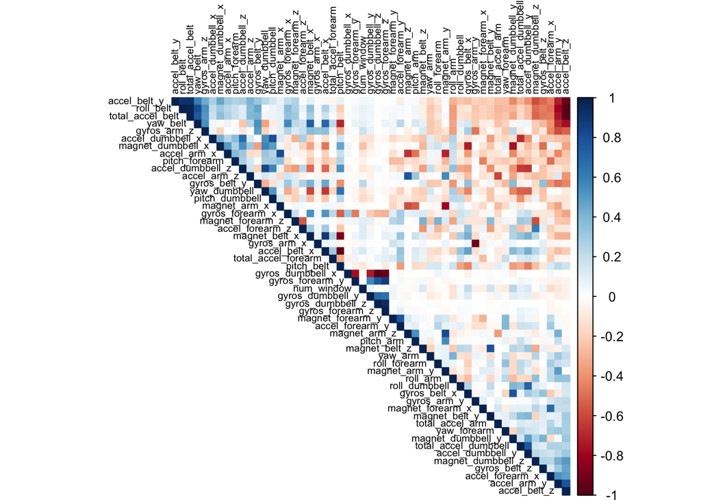

```r
cor_vars <- cor(TrainSet[, -54])
corrplot(cor_vars, order = "FPC", method = "color", type = "upper", tl.cex = 0.6, tl.col = rgb(0, 0, 0))
```

Magnet_forearm_Y and accel_forearm_Y; these two variables are highly correlated.Including both these predictors may not be very useful. A weighted combo (PCA analysis)of predictors should capture most information, reduce number of predictors and reduced noise due to averaging.

## Subsetting variables with high positive correlations.

```r
highcorr<- findCorrelation(cor_vars, cutoff = 0.75)
highcorr
```

```
##  [1] 11  2 10 23  5 37  9  3 38 36 39 35 22 24 26 14 49 46 32 34 19
```

```r
names(TrainSet[highcorr])
```

```
##  [1] "accel_belt_z"      "roll_belt"         "accel_belt_y"
##  [4] "accel_arm_y"       "total_accel_belt"  "accel_dumbbell_z"
##  [7] "accel_belt_x"      "pitch_belt"        "magnet_dumbbell_x"
## [10] "accel_dumbbell_y"  "magnet_dumbbell_y" "accel_dumbbell_x"
## [13] "accel_arm_x"       "accel_arm_z"       "magnet_arm_y"
## [16] "magnet_belt_z"     "accel_forearm_y"   "gyros_forearm_y"
## [19] "gyros_dumbbell_x"  "gyros_dumbbell_z"  "gyros_arm_x"
```

# Model building

For this project, we will use the following algorithms: Decision trees, Random Forest and genrealised boosted regression model (gbm).

## Predicting with Decision tree.

```r
library(rpart)
library(rattle)
```

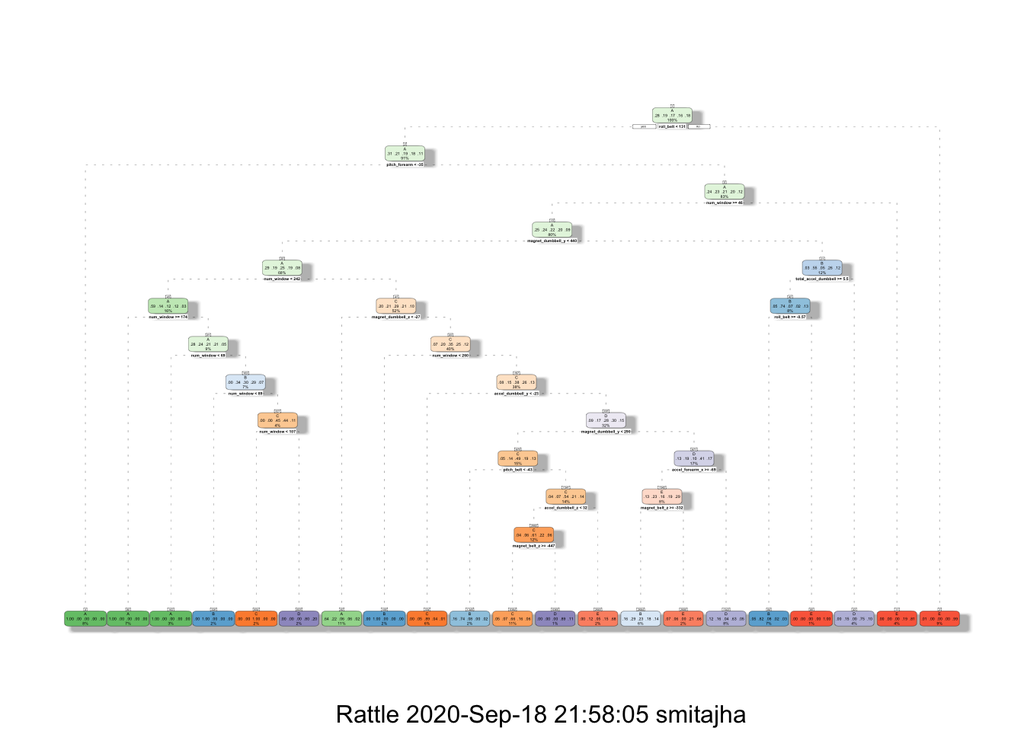

```r
set.seed(2345)
modFit1<-rpart(classe ~., data=TrainSet, method="class")
fancyRpartPlot(modFit1)
```

## prediction on Test dataset

```r
library(e1071)
predictTree <- predict(modFit1, newdata = TestSet, type = "class")
confTree <- confusionMatrix(predictTree, as.factor(TestSet$classe))
confTree
```

```
## Confusion Matrix and Statistics
##
##           Reference
## Prediction    A    B    C    D    E
##          A 1479  143   47   49   13
##          B   92  805  126   93   69
##          C   27   49  817  124   50
##          D   59  112   32  598   98
##          E   17   30    4  100  852
##
## Overall Statistics
##
##                Accuracy : 0.7733
##                  95% CI : (0.7624, 0.784)
##     No Information Rate : 0.2845
##     P-Value [Acc > NIR] : < 2.2e-16
##
##                   Kappa : 0.7128
##
##  Mcnemar's Test P-Value : < 2.2e-16
##
## Statistics by Class:
##
##                      Class: A Class: B Class: C Class: D Class: E
## Sensitivity            0.8835   0.7068   0.7963   0.6203   0.7874
## Specificity            0.9402   0.9199   0.9485   0.9388   0.9686
## Pos Pred Value         0.8544   0.6793   0.7657   0.6652   0.8495
## Neg Pred Value         0.9531   0.9289   0.9566   0.9266   0.9529
## Prevalence             0.2845   0.1935   0.1743   0.1638   0.1839
## Detection Rate         0.2513   0.1368   0.1388   0.1016   0.1448
## Detection Prevalence   0.2941   0.2014   0.1813   0.1528   0.1704
## Balanced Accuracy      0.9118   0.8133   0.8724   0.7796   0.8780
```

## Plot the matrix results.

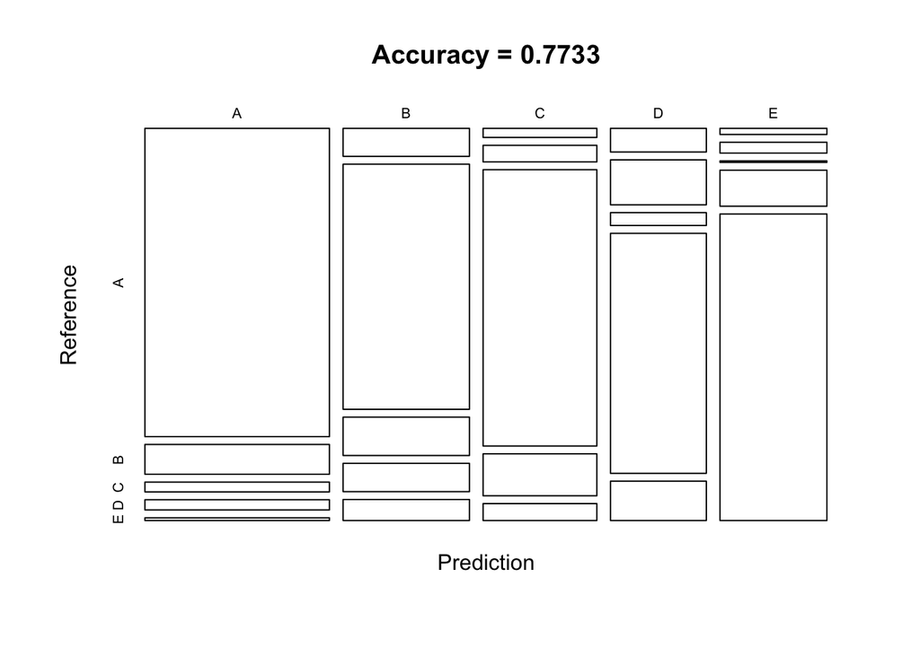

```r
plot(confTree$table, col=confTree$byClass, main=paste("Accuracy =", round(confTree$overall['Accuracy'], 4)))
```

## Using ML algorithm, Random Forest for prediction.

```r
library(randomForest)
modFit <- train(classe ~., method="rf", data=TrainSet, trControl=trainControl(method='cv'), number=5, allowParallel=TRUE )
modFit$finalModel
```

```
##
## Call:
##  randomForest(x = x, y = y, mtry = param$mtry, number = 5, allowParallel = TRUE)
##                Type of random forest: classification
##                      Number of trees: 500
## No. of variables tried at each split: 27
##
##         OOB estimate of  error rate: 0.28%
## Confusion matrix:
##      A    B    C    D    E  class.error
## A 3904    1    0    0    1 0.0005120328
## B   10 2646    2    0    0 0.0045146727
## C    0    4 2392    0    0 0.0016694491
## D    0    0   11 2241    0 0.0048845471
## E    0    4    0    5 2516 0.0035643564
```

##Apply the above model fit to the test data set.

```r
library(e1071)
predictRF <- predict(modFit, newdata = TestSet)
confRF <- confusionMatrix(predictRF, as.factor(TestSet$classe))
confRF
```

```
## Confusion Matrix and Statistics
##
##           Reference
## Prediction    A    B    C    D    E
##          A 1674    2    0    0    0
##          B    0 1136    1    0    0
##          C    0    1 1025    7    0
##          D    0    0    0  957    4
##          E    0    0    0    0 1078
##
## Overall Statistics
##
##                Accuracy : 0.9975
##                  95% CI : (0.9958, 0.9986)
##     No Information Rate : 0.2845
##     P-Value [Acc > NIR] : < 2.2e-16
##
##                   Kappa : 0.9968
##
##  Mcnemar's Test P-Value : NA
##
## Statistics by Class:
##
##                      Class: A Class: B Class: C Class: D Class: E
## Sensitivity            1.0000   0.9974   0.9990   0.9927   0.9963
## Specificity            0.9995   0.9998   0.9984   0.9992   1.0000
## Pos Pred Value         0.9988   0.9991   0.9923   0.9958   1.0000
## Neg Pred Value         1.0000   0.9994   0.9998   0.9986   0.9992
## Prevalence             0.2845   0.1935   0.1743   0.1638   0.1839
## Detection Rate         0.2845   0.1930   0.1742   0.1626   0.1832
## Detection Prevalence   0.2848   0.1932   0.1755   0.1633   0.1832
## Balanced Accuracy      0.9998   0.9986   0.9987   0.9960   0.9982
```

## Plot the RF model

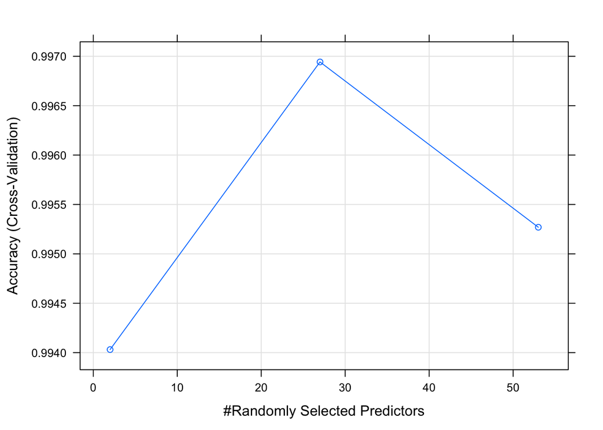

```r
plot(modFit)
```

##Prediction with Generalized Boosted Regression Models RF model already looks like a good prediction model, but we will go ahead and try one more ML algorithm.

```r
library(gbm)
set.seed(12345)
ctrlGBM <- trainControl(method = "repeatedcv", number = 5, repeats = 1)
modGBM  <- train(classe ~ ., data=TrainSet, method = "gbm", trControl = ctrlGBM, verbose = FALSE)
modGBM$finalModel
```

```
## A gradient boosted model with multinomial loss function.
## 150 iterations were performed.
## There were 53 predictors of which 52 had non-zero influence.
```

```r
predictGBM <- predict(modGBM, newdata=TestSet)
cmGBM <- confusionMatrix(predictGBM, as.factor (TestSet$classe))
cmGBM
```

```
## Confusion Matrix and Statistics
##
##           Reference
## Prediction    A    B    C    D    E
##          A 1669   13    0    3    0
##          B    5 1114    8    8    7
##          C    0   10 1013   15    3
##          D    0    2    5  938   14
##          E    0    0    0    0 1058
##
## Overall Statistics
##
##                Accuracy : 0.9842
##                  95% CI : (0.9807, 0.9872)
##     No Information Rate : 0.2845
##     P-Value [Acc > NIR] : < 2.2e-16
##
##                   Kappa : 0.98
##
##  Mcnemar's Test P-Value : NA
##
## Statistics by Class:
##
##                      Class: A Class: B Class: C Class: D Class: E
## Sensitivity            0.9970   0.9781   0.9873   0.9730   0.9778
## Specificity            0.9962   0.9941   0.9942   0.9957   1.0000
## Pos Pred Value         0.9905   0.9755   0.9731   0.9781   1.0000
## Neg Pred Value         0.9988   0.9947   0.9973   0.9947   0.9950
## Prevalence             0.2845   0.1935   0.1743   0.1638   0.1839
## Detection Rate         0.2836   0.1893   0.1721   0.1594   0.1798
## Detection Prevalence   0.2863   0.1941   0.1769   0.1630   0.1798
## Balanced Accuracy      0.9966   0.9861   0.9908   0.9844   0.9889
```

Plot the gbm model.

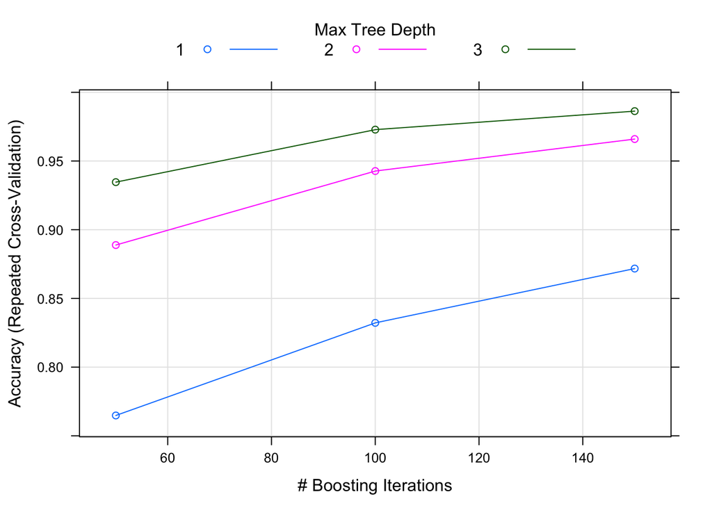

```r
plot(modGBM)
```

## The accuracy rate of RF model is the highest, compared to the other two models. So, we will use the RF model to test the required/provided cases.

Note that Test data (Qdata) is minimally processed (removing NAs.

```r
Results <- predict(modFit, newdata=Qdata)
Results
```

```
##  [1] B A B A A E D B A A B C B A E E A B B B
## Levels: A B C D E
```

This predicted model matches with the course project prediction quiz.